# 傻瓜式评分卡2.0

cr.Cai, 2020-09-07

## coding开篇语 - 致谢

- 感谢玉琪爸爸、鹏哥和王老师的good idea与Dead line。
- 感谢macbook，忍受了一遍又一遍的分箱。
- 感谢我的头发，她还在。

### Y need this？

- 因为行方对模型选择永远专一
- 因为行方的建模环境太差

### 温馨提示

1. 本代码不适合在集群上跑
2. 本代码不建议超过200M的txt数据**(500G内存服务器当主机的土豪请忽略)**
3. 本代码不建议超过10W行的txt数据(同上，500G内存服务器当主机的土豪请忽略)

### step0：基本介绍

环境准备

1. python3.6以上
2. scorecardpy，https://github.com/ShichenXie/scorecardpy
3. PrettyTable，https://pypi.org/project/PrettyTable/

demo简介：

1. 某爸爸提供的假样本数据，风控贷前
2. 特征：763

```python
import warnings
warnings.filterwarnings("ignore")
```

```python
import pandas as pd
import numpy as np

import matplotlib as mpl
mpl.rcParams['font.sans-serif'] = ['SimHei']  # 指定默认字体
mpl.rcParams['axes.unicode_minus'] = False
import json

from sklearn.model_selection import train_test_split
```

```python
pro_path = "/Users/cai/Desktop/pythonProjects/github_FoolishCai/scModel"
import sys
import os
sys.path.append(pro_path)

from scToolkits.edaToolkit import EdaUtil as EDA
from scToolkits.FastScToolkit import FastScWoe as FSW
from scToolkits.drawToolkit import plot_learning_curve, get_correlation, get_feature_importance, get_lift_curve, get_plt_kde, get_pr_curve, get_score_bar
```

### step1: 读取数据

```python
df = pd.read_csv("/Users/cai/Desktop/工作projects/1.2.工作备份/测试数据.csv", sep="|", dtype=str)
df = df.drop(['age', 'sex'], axis=1)

df_bak = df.copy()

config_df = pd.read_csv(pro_path + os.sep + "Configs/import_miss_763.txt", sep=",")
config_df = config_df[config_df.in763==1]
del_col = ["number", "id", "id_type", "create_date", "gid", "y"]
# 连续变量
serial_col = list(config_df[config_df.if_continuous==1].feature)
serial_col = [i for i in serial_col if i not in del_col and i in df.columns]
# 离散变量
dist_col =  list(config_df[config_df.if_continuous==0].feature)
dist_col = [i for i in dist_col if i not in del_col and i in df.columns]
```

#### note1.1：为保持与线上一致，手动填写na

```python
with open(pro_path + os.sep + "Configs/fill_na.json","r") as f:
    naj = json.load(f)

# {'ft_gz_consumption_capacity': 999,
#  'ft_gz_income_1': 999,
#  'ft_lbs_house_price': 6,
#  'ft_lbs_property_fee': 6,
#  'ft_lbs_same_night_stay_wifimac_cnt': 2.5,
#  'ft_lbs_stable_stops': 2.5,
#  'ft_social_blackfriends': 0.9,
#  'ft_social_blackfriends_group': 0.9,
#  'ft_stable_imsi_changes': 2.5,
#  'ft_gz_car_price': 999,
#  'ft_gz_sensitive_area': 3.5}


for col in naj.keys():
    df[col].replace(float(naj[col]), np.nan, inplace=True)
    df[col].replace(str(naj[col]), np.nan, inplace=True)
```

### step2: EDA

#### note2.1 EDA基本要求

- 是否有时间单位，观察单位时间内的y1变化情况，判断是否可以作ott验证
- 样本的缺失率情况，横纵两个方向，在特征维度上删除覆盖率低于20%的特征
- 不同label下的特征缺失率分布，考虑特征缺失是否可以作为前置规则**(cr.chengp)**
- 对于离散变量
  - 查找unique value过多的离散特征
  - 查找除了np.nan以外仅有唯一值的离散特征
- 连续变量（查找没啥变化的连续变量）
  - 某一特征非空的连续数值，五分位数与95分位数相等
  - 变异系数(Coefficient of Variation, cv)过小**(cr. wangmj)**

```python
ls ../logs
```

```
EDA.log              scModel20200929.log
```

```python
eda = EDA(file_name="EDA",  df=df.copy(), target_name="y", del_col=del_col, dist_col=dist_col, serial_col=serial_col, time_col="create_date",
                 time_level="m", max_col_null_pct=0.8, max_row_null_pct=0.8,
                 max_null_pct_delta=0.1, max_various_values=20)
```

```
2020-09-29 11:55:19,275 LogUtil.py [line:38] INFO 所有样本均有Y值
2020-09-29 11:55:19,277 LogUtil.py [line:38] INFO 但请不要得瑟，数据已经有了，模型，嘿嘿嘿～
2020-09-29 11:55:19,278 LogUtil.py [line:38] INFO **************************************************
2020-09-29 11:55:19,347 LogUtil.py [line:38] INFO 样本共有19个时间单位，具体说明如下
```

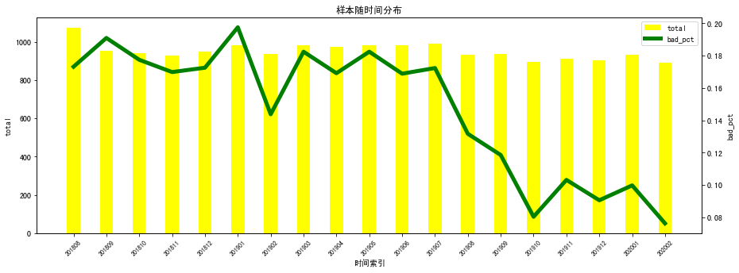

```
2020-09-29 11:55:19,705 LogUtil.py [line:38] INFO **************************************************
2020-09-29 11:55:20,155 LogUtil.py [line:38] INFO 样本整体缺失率情况如下:
```

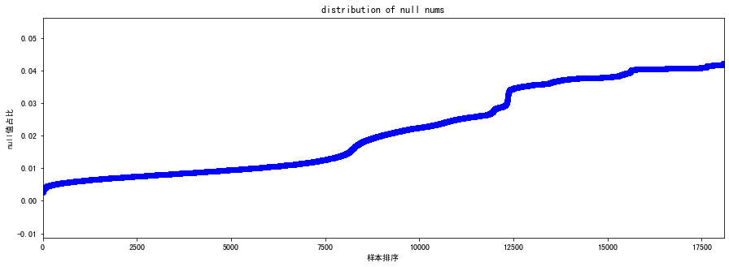

```
2020-09-29 11:55:20,383 LogUtil.py [line:38] INFO **************************************************
2020-09-29 11:55:20,824 LogUtil.py [line:38] INFO 不同label下样本整体缺失情况如下:
```

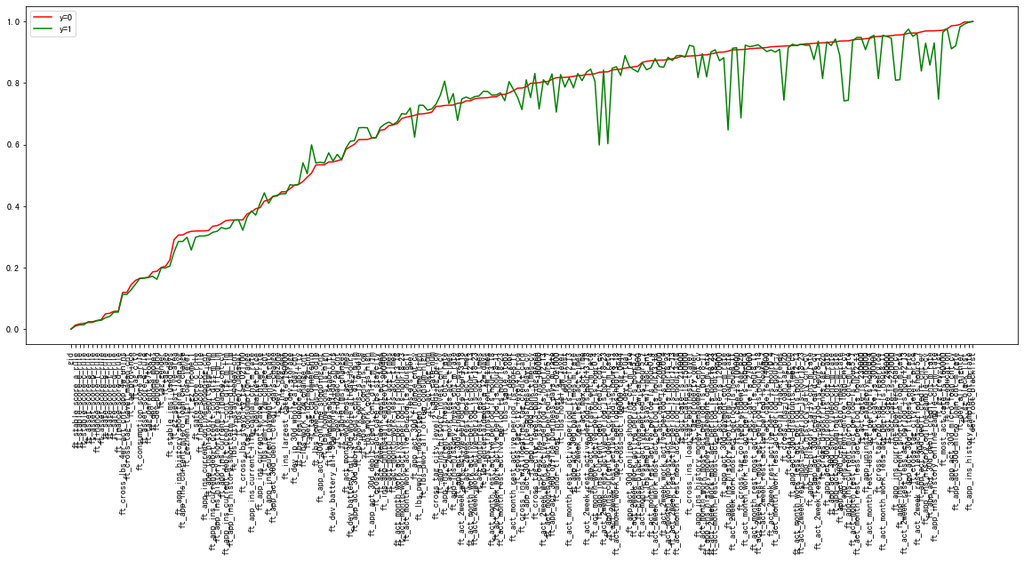

```
2020-09-29 11:55:23,134 LogUtil.py [line:38] INFO 有15个特征在好坏样本上缺失值(高于0.1)差异明显
2020-09-29 11:55:23,136 LogUtil.py [line:38] INFO 不同label下的缺失值情况如下
:+--------------------------------------------+--------------------+--------------------+---------------------+
|                                            |      label_0       |      label_1       |        delta        |
+--------------------------------------------+--------------------+--------------------+---------------------+
|     ft_andr_t1_most_interest_ls_021000     | 0.8171721763979997 | 0.7054667162513946 |  0.1117054601466051 |
|   ft_app_ins_current_debit_credit_cnt_cv   | 0.8349678508800416 | 0.5983637039791744 | 0.23660414690086717 |
| ft_app_ins_current_debit_credit_cnt_m_rate | 0.8363317529388842 | 0.602826329490517  | 0.23350542344836722 |
|  ft_app_ins_history_shortterm_loan_m_rate  | 0.9038124309930506 | 0.647452584603942  |  0.2563598463891087 |
|    ft_cross_tag_college_student_tag_p2p    | 0.9089433006429825 | 0.686500557828189  | 0.22244274281479348 |
|         ft_cross_ins_loan_tag_p2p          | 0.9202442034162499 | 0.744142804016363  |  0.1761013993998869 |
|       ft_cross_blackfriends_tag_p2p        | 0.930635838150289  | 0.814801041279286  | 0.11583479687100307 |
|    ft_app_ins_current_micro_loan_cnt_cv    | 0.9368708189907125 | 0.7415396058014132 | 0.19533121318929925 |
|  ft_app_ins_current_micro_loan_cnt_m_rate  | 0.9373254530103267 | 0.744142804016363  | 0.19318264899396365 |
|      ft_cross_tag_p2p_tag_lifeservice      | 0.9516788984867182 | 0.8144291558200074 | 0.13724974266671075 |
|    ft_app_ins_current_shortterm_loan_cv    | 0.9559654478145093 | 0.8092227593901078 | 0.14674268842440152 |
|  ft_app_ins_current_shortterm_loan_m_rate  | 0.9563551341170358 | 0.810710301227222  | 0.14564483288981378 |
|     ft_app_act_30d_debit_credit_cnt_cv     | 0.9662921348314607 | 0.8389735961323912 |  0.1273185386990695 |
|   ft_app_act_30d_debit_credit_cnt_m_rate   | 0.9696694161200233 | 0.8583116400148754 | 0.11135777610514797 |
|              ft_gz_grey_list               | 0.970773527310515  | 0.7474897731498699 | 0.22328375416064516 |
+--------------------------------------------+--------------------+--------------------+---------------------+
2020-09-29 11:55:23,136 LogUtil.py [line:38] INFO **************************************************
2020-09-29 11:55:48,850 LogUtil.py [line:38] INFO 有32个特征为唯一值,分别如下['ft_act_2week_rest_most_act_period_ls_hour13_18', 'ft_act_month_rest_most_act_period_ls_hour8_11', 'ft_act_2week_rest_less_act_period_ls_hour5_7', 'ft_act_2week_rest_less_act_period_ls_hour12_13', 'ft_act_month_rest_less_act_period_ls…
2020-09-29 11:55:48,853 LogUtil.py [line:38] INFO **************************************************
2020-09-29 11:55:48,854 LogUtil.py [line:38] INFO 有18个离散特征值过多,分别如下['ft_app_act_30d_debit_credit_days_change', 'ft_app_ins_current_micro_loan_cnt_change', 'ft_app_act_30d_micro_loan_cnt_change', 'ft_app_act_30d_debit_credit_times_change', 'ft_tag_city', 'ft_app_act_30d_micro_loan_days_change', 'ft_ap…
2020-09-29 11:55:48,854 LogUtil.py [line:38] INFO **************************************************
2020-09-29 11:55:48,855 LogUtil.py [line:38] INFO 有116个连续特征无明显差异,分别如下['ft_app_ins_current_gamble_cnt', 'ft_app_ins_history_gamble_cnt', 'ft_app_ins_current_lottery_cnt', 'ft_app_ins_current_tally_cnt', 'ft_app_ins_current_online_gamble_cnt', 'ft_app_act_30d_insurance_cnt', 'ft_app_act_30d_insurance_…
2020-09-29 11:55:48,856 LogUtil.py [line:38] INFO **************************************************
2020-09-29 11:55:49,052 LogUtil.py [line:38] INFO 缺失值比例>0.8的有5670行
2020-09-29 11:55:49,132 LogUtil.py [line:38] INFO 全局label1的占比为:0.1487
2020-09-29 11:55:49,134 LogUtil.py [line:38] INFO 特征饱和度低于0.8的样本label1的占比为:0.1416
2020-09-29 11:55:49,135 LogUtil.py [line:38] INFO **************************************************
2020-09-29 11:55:49,281 LogUtil.py [line:38] INFO 缺失值比例>0.8的有121个变量
2020-09-29 11:55:49,507 LogUtil.py [line:38] INFO 每列缺失值情况如下:
+------------------------------------------------+---------+----------+----------+--------------------+
|                                                |  dtype  | data_cnt | null_cnt |     null_ratio     |
+------------------------------------------------+---------+----------+----------+--------------------+
|             ft_dev_root_blacklist              |  object |  18086   |  18086   |        1.0         |
|        ft_app_ins_history_gamble_cnt_cv        | float64 |  18086   |  18058   | 0.9984518412031406 |
|      ft_app_ins_history_gamble_cnt_m_rate      | float64 |  18086   |  18058   | 0.9984518412031406 |
```

[output cut: 112 more lines]

```
|  ft_act_2week_work_active_period_ls_hour12_13  | float64 |  18086   |  14565   | 0.8053190312949242 |
|     ft_cross_tag_city_level3_housing_price     |  object |  18086   |  14549   | 0.8044343691252903 |
|         ft_cross_tag_city_level3_price         |  object |  18086   |  14549   | 0.8044343691252903 |
|   ft_act_month_work_active_period_ls_hour5_7   | float64 |  18086   |  14527   | 0.8032179586420436 |
|   ft_app_ins_current_debit_credit_cnt_m_rate   | float64 |  18086   |  14498   | 0.801614508459582  |
|       ft_andr_t1_most_interest_ls_021000       |  object |  18086   |  14479   | 0.8005639721331417 |
+------------------------------------------------+---------+----------+----------+--------------------+
2020-09-29 11:55:49,508 LogUtil.py [line:38] INFO **************************************************
2020-09-29 11:55:49,522 LogUtil.py [line:38] INFO 本次EDA，可供参考的数据信息有以下
2020-09-29 11:55:49,522 LogUtil.py [line:38] INFO 无法转化为连续(float)的特征: EdaUtil.dist_col
2020-09-29 11:55:49,523 LogUtil.py [line:38] INFO 有唯一值的特征: EdaUtil.single_cols
2020-09-29 11:55:49,524 LogUtil.py [line:38] INFO value值过多的特征: EdaUtil.various_cols
2020-09-29 11:55:49,524 LogUtil.py [line:38] INFO 分布无明显变化的特征: EdaUtil.q5equalq95_col
2020-09-29 11:55:49,525 LogUtil.py [line:38] INFO 缺失率过高的特征: EdaUtil.to_drop_cols
2020-09-29 11:55:49,525 LogUtil.py [line:38] INFO 缺失率过高的行: EdaUtil.to_drop_rows
```

```python
eda.go_init_explore()
```

```python
to_drop_cols = eda.single_cols + eda.q5equalq95_col + [i[0] for i in eda.to_drop_cols] + eda.various_cols
```

### step3: WoeCut & Model

#### note3.1 爸爸普适性要求

- 分箱单调或U型
  - 离散的数值型是否需要单调
  - 离散变量是否可以合并
- iv，阈值设定在0.02
- corr，阈值设定在0.6
- vif在0.7
- 逐步回归，不管是statmodel.logit还是sklearn.LogisticRegression的，最后特征系数同向(woe计算的时候决定)
- np.nan是否归并为一箱
  - 除掉np.nan，至少还剩余两箱
- 无法映射的数值作何处理？
  - 删除，应作特征质量监控

```python
df = df_bak.copy()
df["y"] = df.y.astype(float).astype(int)
```

```python
df = df.drop(to_drop_cols, axis=1)

if  "ft_lbs_residence_stability" not in to_drop_cols:
    df["ft_lbs_residence_stability"] = df.ft_lbs_residence_stability.map(lambda x: int(bool(x)) if x==x else np.nan)
if "ft_lbs_workplace_stability" not in to_drop_cols:
    df["ft_lbs_workplace_stability"] = df.ft_lbs_workplace_stability.map(lambda x: int(bool(x)) if x==x else np.nan)

_del = [i for i in del_col if i in df.columns]
_serial = [i for i in serial_col if i not in to_drop_cols]
_dist = [i for i in dist_col if i not in to_drop_cols]
```

```python
X_train, X_test, y_train, y_test = train_test_split(df[_serial + _dist + ["y"]], df[["y"]], test_size=0.33, random_state=222, stratify=df.create_date)

print("Train-data: shape={}, y_ratio={}".format(X_train.shape, round(y_train.y.sum()/len(y_train), 4)))
print("Test-data:  shape={}, y_ratio={}".format(X_test.shape, round(y_test.y.sum()/len(y_test), 4)))
```

```
Train-data: shape=(12117, 515), y_ratio=0.1467
Test-data:  shape=(5969, 515), y_ratio=0.1526
```

```python
fsw = FSW(df_train=X_train, target_name="y", dist_col=_dist, serial_col=_serial, df_test=X_test,
          df_ott=None, max_corr=0.6)
```

```
2020-09-29 11:55:52,539 LogUtil.py [line:38] INFO 好棒！没有跨时间验证窗口的数据～
```

```python
fsw.cut_main()
```

```
2020-09-29 11:55:52,672 LogUtil.py [line:38] INFO 现在是分5箱, 有514个变量需要分箱
```

```
[INFO] creating woe binning ...
Binning on 12117 rows and 515 columns in 00:00:54
```

```
2020-09-29 11:56:49,218 LogUtil.py [line:38] INFO 现在是分4箱, 有236个变量需要分箱
```

```
[INFO] creating woe binning ...
Binning on 12117 rows and 237 columns in 00:00:38
```

```
2020-09-29 11:57:27,989 LogUtil.py [line:38] INFO 现在是分3箱, 有235个变量需要分箱
```

```
[INFO] creating woe binning ...
Binning on 12117 rows and 236 columns in 00:00:30
```

```
2020-09-29 11:57:58,765 LogUtil.py [line:38] INFO 仍有217个特征无法满足单调的需求，不能分箱
2020-09-29 11:57:58,989 LogUtil.py [line:38] INFO **************************************************
2020-09-29 11:57:58,990 LogUtil.py [line:38] INFO WOE Detail can be checked in scModel20200929_bin_result.xlsx
```

```
[INFO] converting into woe values ...
Woe transformating on 12117 rows and 514 columns in 00:00:13
[INFO] converting into woe values ...
```

```
2020-09-29 11:58:37,025 LogUtil.py [line:38] INFO CutBin has finished!
```

```python
fsw.model_main()
```

```
2020-09-29 11:58:37,045 LogUtil.py [line:38] INFO 有141个特征iv值小于0.02
2020-09-29 11:58:37,698 LogUtil.py [line:38] INFO TestData有3个样本仍含有缺失值，暂删除，占比0.0005
2020-09-29 11:58:38,300 LogUtil.py [line:38] INFO 根据iv删除45个相关性较高的特征
```

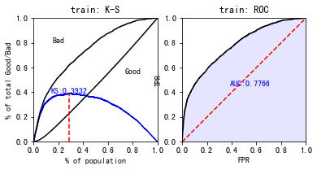

```
On train-data, the evaluation follows:
ks=0.3932, auc=0.7766, gini=0.5533
```

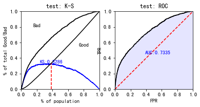

```
On test-data, the evaluation follows:
ks=0.3286, auc=0.7335, gini=0.467
```

```
2020-09-29 11:59:20,595 LogUtil.py [line:38] INFO 全部环节结束，请查看相关文件！
```

```python
fsw.evaluate_main()
```

```python
fsw.card2sql(table_name="<table_name>", id_col="id")
```

```
2020-09-29 12:00:36,163 LogUtil.py [line:38] INFO 映射分数，共有25个特征，其中连续特征7个，离散特征18个。
```

```
>>>>>>>>>>>>>>>>>>>>>>>>>>>>>>>>> card2SQL 生成如下：
 select *, (449 + ft_app_ins_history_debit_credit_cnt + ft_gezhen_multi_loan_level + ft_cross_lbs_staycity_tag_021700 + parent + ft_asset_score_a_rule + ft_tag_stock + ft_tag_marrige + ft_cross_ins_wifilocating_tag_credit_card + ft_cross_most_act_cate_lbs_staycity + ft_gz_sensitive_area + ft_app_act…
 from (select id
,(case when float(ft_app_ins_history_debit_credit_cnt) is null then 2 when float(ft_app_ins_history_debit_credit_cnt)<1.0 then 17 when float(ft_app_ins_history_debit_credit_cnt)>=1.0 and float(ft_app_ins_history_debit_credit_cnt)<2.0 then 10 when float(ft_app_ins_history_debit_credit_cnt)>=2.0 and f…
,(case when ft_gezhen_multi_loan_level='none' then 6 when ft_gezhen_multi_loan_level ='' or ft_gezhen_multi_loan_level is null then 1 when ft_gezhen_multi_loan_level='low' then -10 when ft_gezhen_multi_loan_level='middle' then -30 when ft_gezhen_multi_loan_level='high' then -41 else null end) as ft_…
,(case when ft_cross_lbs_staycity_tag_021700='4.0' then 7 when ft_cross_lbs_staycity_tag_021700 ='' or ft_cross_lbs_staycity_tag_021700 is null then 1 when ft_cross_lbs_staycity_tag_021700='2.0' then 5 when ft_cross_lbs_staycity_tag_021700='1.0' then -15 when ft_cross_lbs_staycity_tag_021700='3.0' t…
,(case when parent='0.0' then -3 when parent ='' or parent is null then 0 when parent='1.0' then 14 else null end) as parent
,(case when float(ft_asset_score_a_rule) is null then -1 when float(ft_asset_score_a_rule)<549.0 then 2 when float(ft_asset_score_a_rule)>=549.0 and float(ft_asset_score_a_rule)<553.0 then 1 when float(ft_asset_score_a_rule)>=553.0  then -2 else null end) as ft_asset_score_a_rule
,(case when ft_tag_stock='0.0' then -3 when ft_tag_stock ='' or ft_tag_stock is null then 1 when ft_tag_stock='1.0' then 14 else null end) as ft_tag_stock
,(case when ft_tag_marrige='2.0' then 2 when ft_tag_marrige='0.0' then 0 when ft_tag_marrige ='' or ft_tag_marrige is null then 0 when ft_tag_marrige='1.0' then -5 else null end) as ft_tag_marrige
,(case when ft_cross_ins_wifilocating_tag_credit_card ='' or ft_cross_ins_wifilocating_tag_credit_card is null then 1 when ft_cross_ins_wifilocating_tag_credit_card='1.0' then -3 when ft_cross_ins_wifilocating_tag_credit_card='2.0' then -2 when ft_cross_ins_wifilocating_tag_credit_card='3.0' then -7…
,(case when ft_cross_most_act_cate_lbs_staycity='2.0' then -3 when ft_cross_most_act_cate_lbs_staycity ='' or ft_cross_most_act_cate_lbs_staycity is null then 0 when ft_cross_most_act_cate_lbs_staycity='16.0' then 0 when ft_cross_most_act_cate_lbs_staycity='4.0' then 5 when ft_cross_most_act_cate_lb…
,(case when ft_gz_sensitive_area='4.0' then 1 when ft_gz_sensitive_area ='' or ft_gz_sensitive_area is null then 5 when ft_gz_sensitive_area='3.5' then -2 when ft_gz_sensitive_area='1.0' then -3 when ft_gz_sensitive_area='2.0' then -1 when ft_gz_sensitive_area='3.0' then -1 else null end) as ft_gz_s…
,(case when float(ft_app_act_30d_allcate_cnt_avg) is null then 0 when float(ft_app_act_30d_allcate_cnt_avg)<4.0 then 1 when float(ft_app_act_30d_allcate_cnt_avg)>=4.0 and float(ft_app_act_30d_allcate_cnt_avg)<7.0 then -1 when float(ft_app_act_30d_allcate_cnt_avg)>=7.0  then -2 else null end) as ft_a…
,(case when float(ft_asset_score_b_rule) is null then -1 when float(ft_asset_score_b_rule)<3.0 then 2 when float(ft_asset_score_b_rule)>=3.0 and float(ft_asset_score_b_rule)<5.0 then 1 when float(ft_asset_score_b_rule)>=5.0 and float(ft_asset_score_b_rule)<6.0 then -1 when float(ft_asset_score_b_rul…
,(case when ft_ins_app_uninstall_category_160000 ='' or ft_ins_app_uninstall_category_160000 is null then 0 when ft_ins_app_uninstall_category_160000='0.0' then 0 when ft_ins_app_uninstall_category_160000='1.0' then 0 else null end) as ft_ins_app_uninstall_category_160000
,(case when float(ft_dev_battery_use_90d_whole_nighttime_hours) is null then 0 when float(ft_dev_battery_use_90d_whole_nighttime_hours)<1.0 then 3 when float(ft_dev_battery_use_90d_whole_nighttime_hours)>=1.0 and float(ft_dev_battery_use_90d_whole_nighttime_hours)<9.0 then -1 when float(ft_dev_batte…
,(case when ft_ins_app_install_category_160000 ='' or ft_ins_app_install_category_160000 is null then 0 when ft_ins_app_install_category_160000='0.0' then 3 when ft_ins_app_install_category_160000='1.0' then -5 else null end) as ft_ins_app_install_category_160000
,(case when ft_tag_fitness='0.0' then -1 when ft_tag_fitness ='' or ft_tag_fitness is null then 0 when ft_tag_fitness='1.0' then 11 else null end) as ft_tag_fitness
```

[output cut: 10 more lines]

```python
fsw.level2sql(table_name="<table_name>")
```

```
>>>>>>>>>>>>>>>>>>>>>>>>>>>>>>>>> l2vel2SQL 生成如下：
 select (case when score>324.28 and score<=388.88 then 0
when score>388.88 and score<=410.45 then 1
when score>410.45 and score<=425.3 then 2
when score>425.3 and score<=437.63 then 3
when score>437.63 and score<=448.97 then 4
when score>448.97 and score<=460.3 then 5
when score>460.3 and score<=472.56 then 6
when score>472.56 and score<=487.26 then 7
when score>487.26 and score<=508.37 then 8
when score>508.37 and score<=570.54 then 9 end) as score_level
from <table_name>
```

### step4: 其他指标

#### note4.1 按需采用

- 特征相关系数图示化
- 特征重要性图示化
- 提升曲线图示化
- p-r曲线
- 模型预测概率值分布图示化
- 模型最终业务决策图示化
- 学习曲线

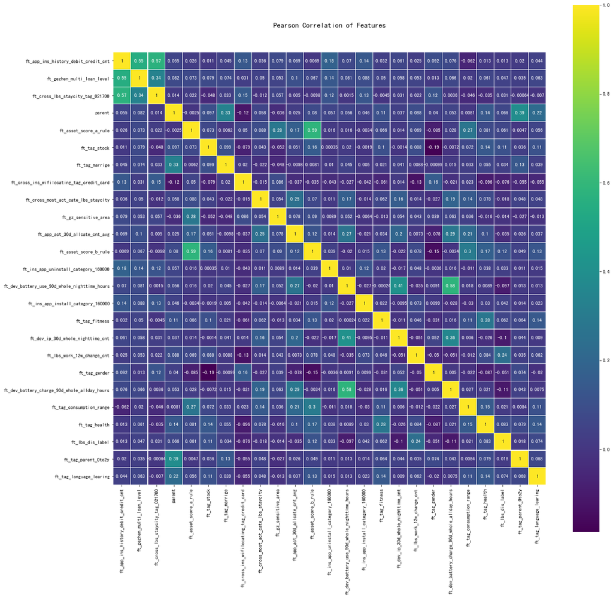

```python
get_correlation(fsw.df_train_woe[fsw.final_features])
```

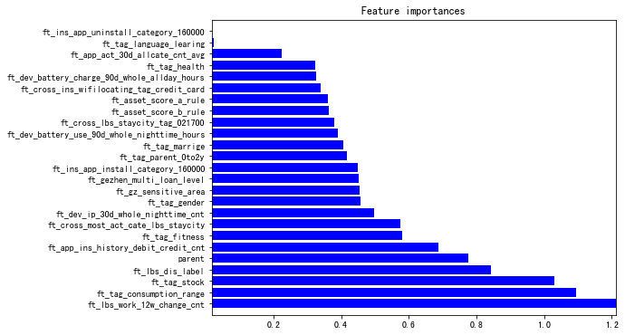

```python
get_feature_importance(fsw.final_features, fsw.model.coef_[0])
```

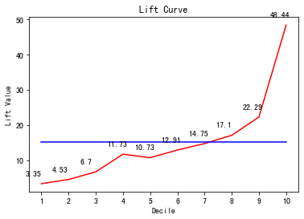

```python
get_lift_curve(y_true = fsw.df_test_woe[fsw.target_name], y_pred = fsw.test_pred)
```

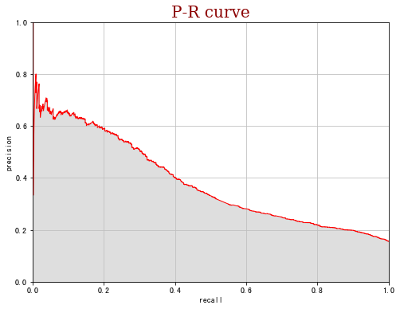

```python
get_pr_curve(y_true = fsw.df_test_woe[fsw.target_name], y_pred = fsw.test_pred)
```

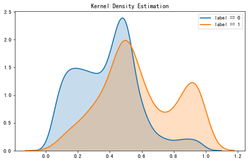

```python
get_plt_kde(y_true = fsw.df_test_woe[fsw.target_name], y_pred = fsw.test_pred)
```

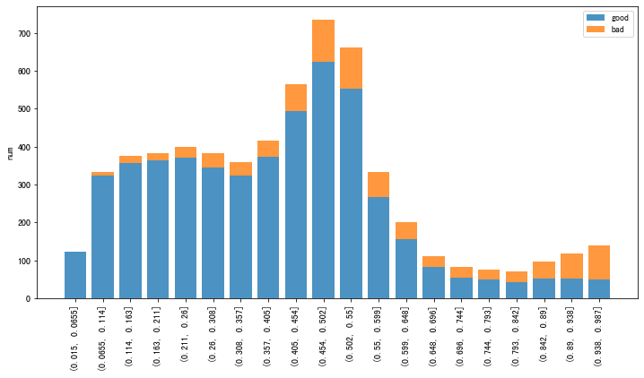

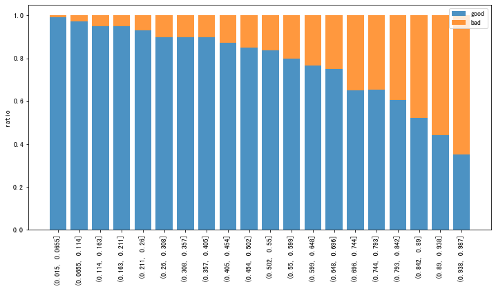

```python
get_score_bar(y_true = fsw.df_test_woe[fsw.target_name], y_pred = fsw.test_pred)
```

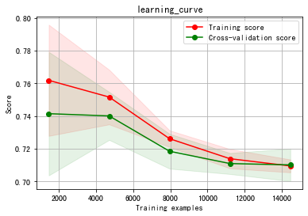

```python
plot_learning_curve(fsw.model, X=pd.concat([fsw.df_train_woe[fsw.final_features], fsw.df_test_woe[fsw.final_features]]),
                   y=pd.concat([fsw.df_train_woe[fsw.target_name], fsw.df_test_woe[fsw.target_name]]))
```

```python
ls
```

```
ScoreCard代码梳理.ipynb          scModel20200910_train.png
scModel20200910_bin_result.xlsx  test_woe.csv
scModel20200910_report.xlsx      train_woe.csv
scModel20200910_test.png
```